# Univariate Plots Section

## Volatile acidity

```
##    Min. 1st Qu.  Median    Mean 3rd Qu.    Max.
##  0.1200  0.3900  0.5200  0.5278  0.6400  1.5800
```

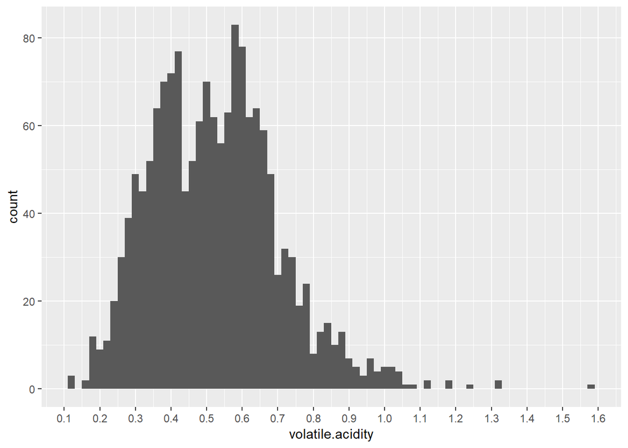

The distribution of volatile acidity appears to be bimodal since it peaks at 0.4 and 0.6. Most observations fall in the range between 0.39 - 0.64 with outliers on the higher end.

## Citric acid

```
##    Min. 1st Qu.  Median    Mean 3rd Qu.    Max.
##   0.000   0.090   0.260   0.271   0.420   1.000
```

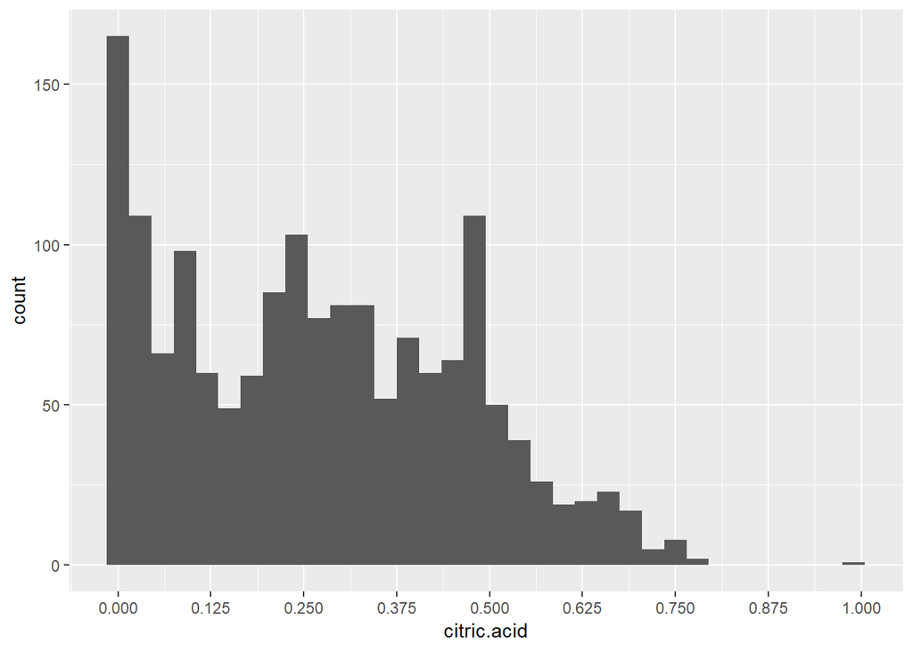

## Residual sugar

```
##    Min. 1st Qu.  Median    Mean 3rd Qu.    Max.
##   0.900   1.900   2.200   2.539   2.600  15.500
```

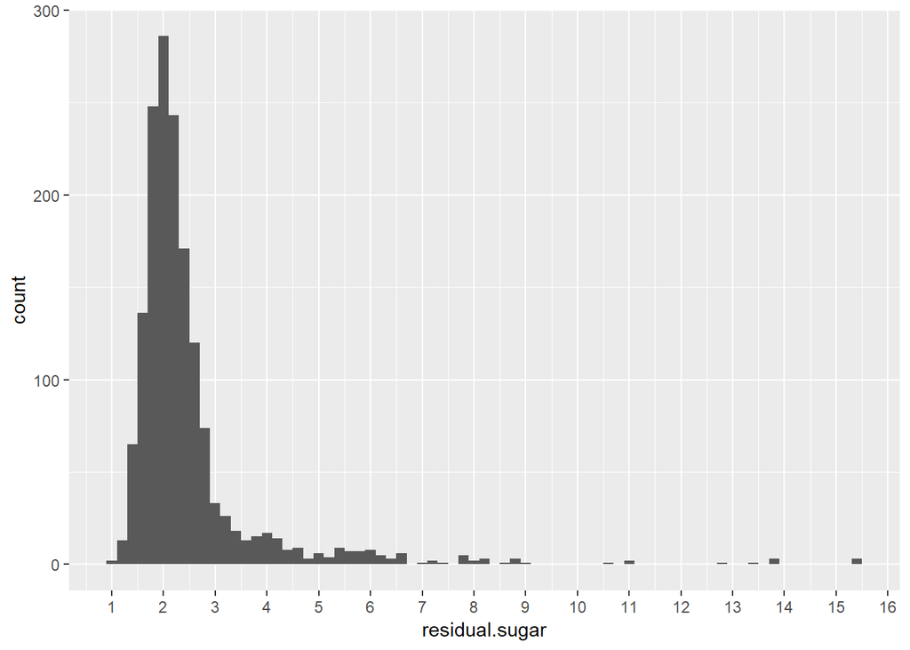

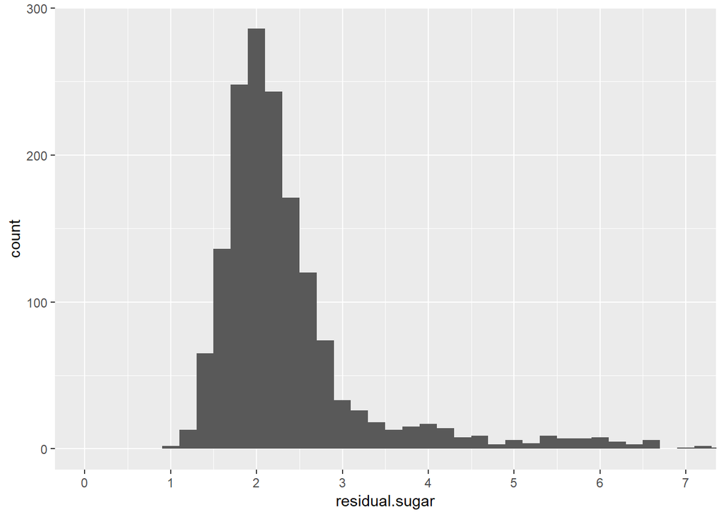

The distribution appears right skewed with a long tail.

## Chlorides

```
##    Min. 1st Qu.  Median    Mean 3rd Qu.    Max.
## 0.01200 0.07000 0.07900 0.08747 0.09000 0.61100
```

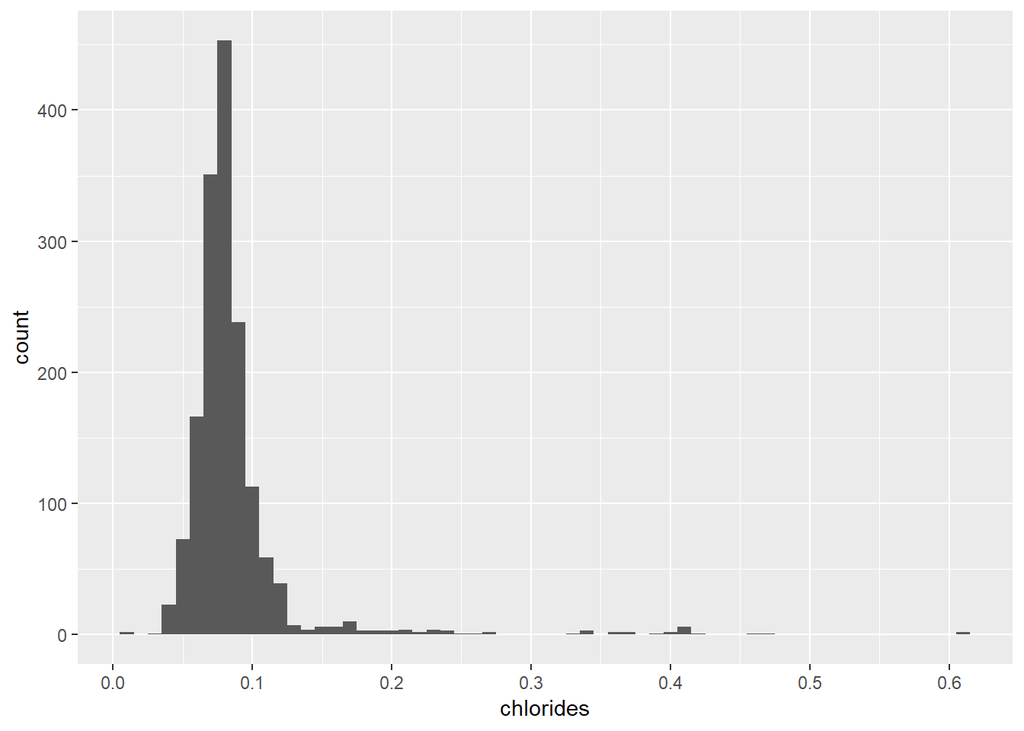

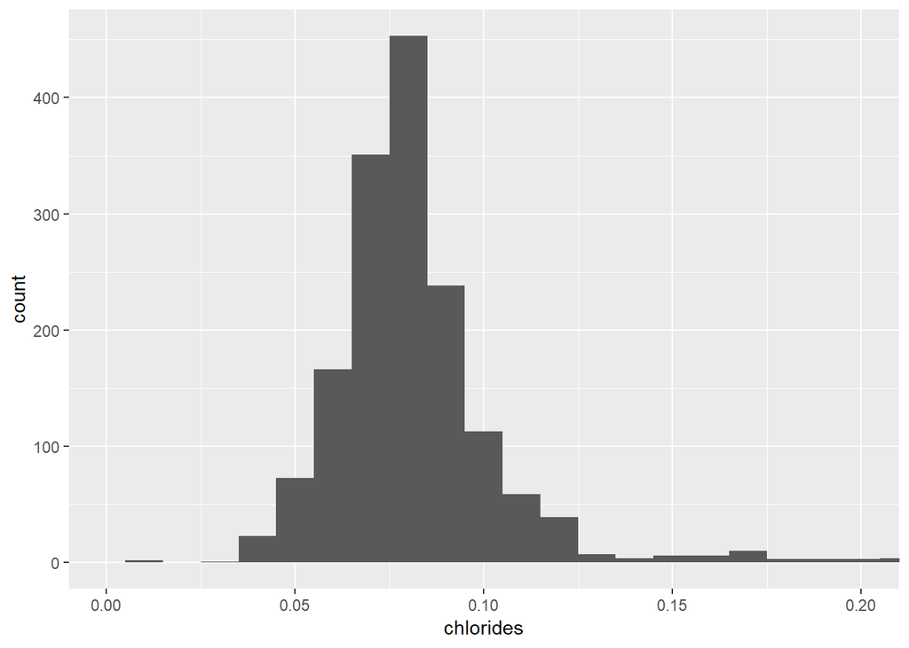

The distribution appears to be normally distributed with a long right tail.

## Free sulfur dioxide

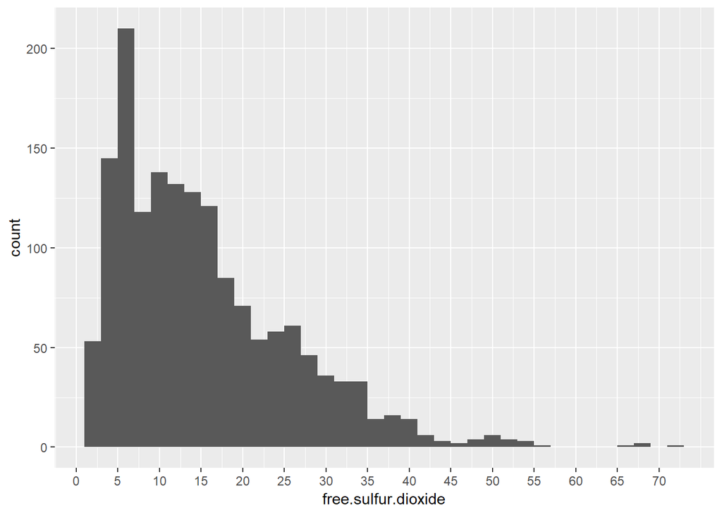

The distribution appears to be right skewed with a long tail, and there seeems to be a gap between 57 and 66.

## Total sulfur dioxide

```
##    Min. 1st Qu.  Median    Mean 3rd Qu.    Max.
##    6.00   22.00   38.00   46.47   62.00  289.00
```

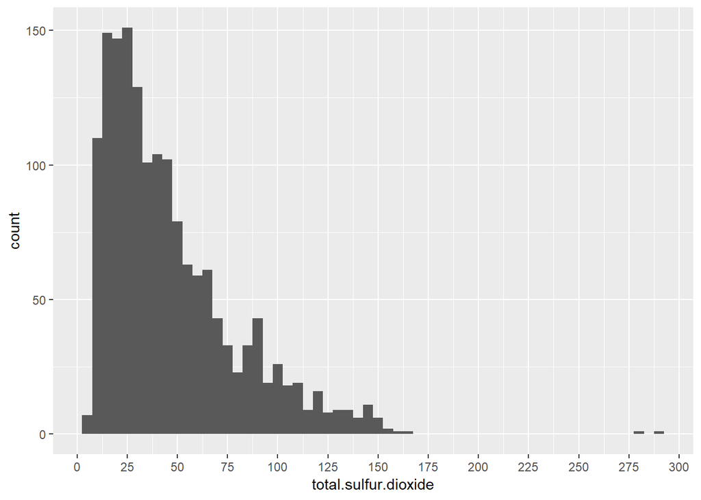

The distribution appears to be right skewed with a long tail. There seems to be a gap between 165 and 278 with only two wines with greater than or equal to 278.

## Density

```
##    Min. 1st Qu.  Median    Mean 3rd Qu.    Max.
##  0.9901  0.9956  0.9968  0.9967  0.9978  1.0037
```

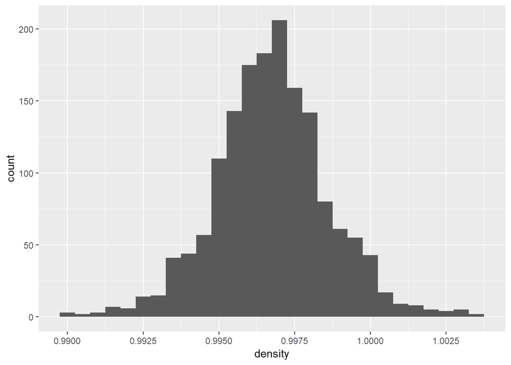

The distribution appears to be slightly symmetrical.

## pH

```
##    Min. 1st Qu.  Median    Mean 3rd Qu.    Max.
##   2.740   3.210   3.310   3.311   3.400   4.010
```

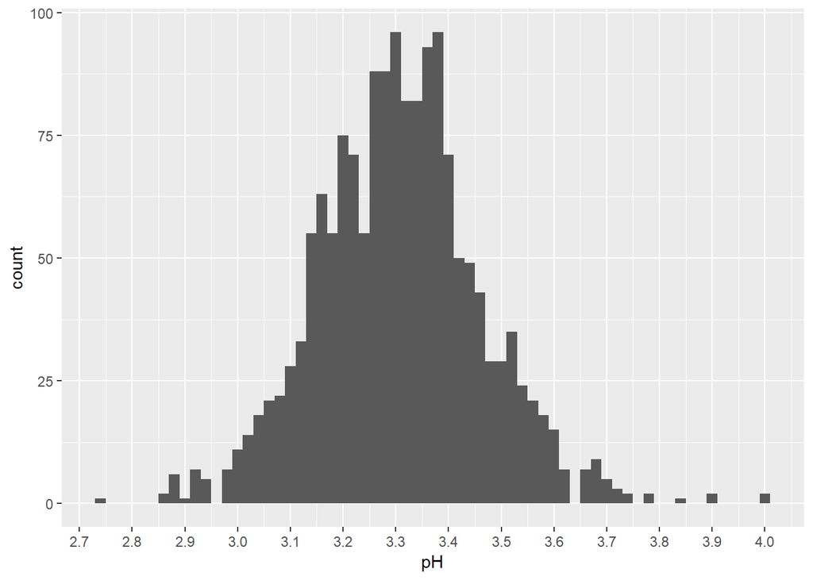

The distribution seems symmetrical or could be also considered bimodal with both peaks very close to each other. Most wines have a pH between 3.21 and 3.4.

## Sulphates

```
##    Min. 1st Qu.  Median    Mean 3rd Qu.    Max.
##  0.3300  0.5500  0.6200  0.6581  0.7300  2.0000
```

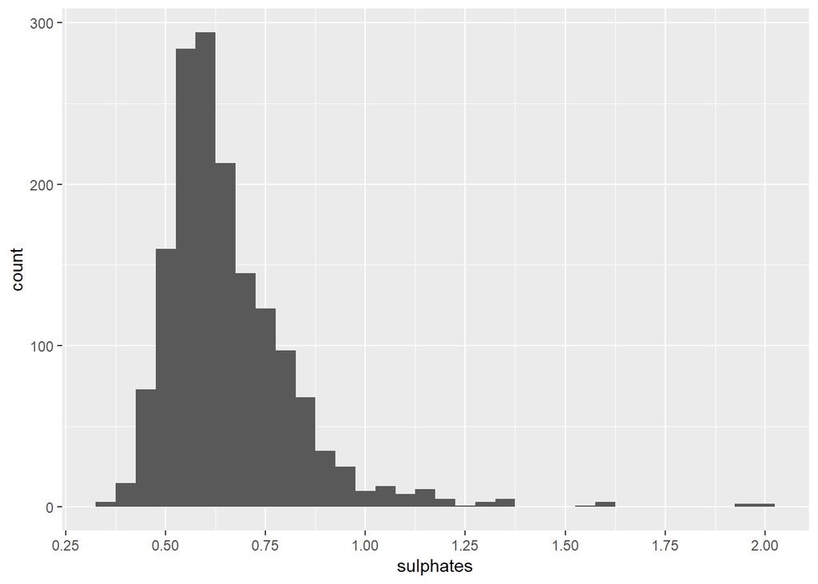

The distribution appears slightly right skewed with a long tail. There are some outliers but most wines have a concentration between 0.55 and 0.73.

## Alcohol

```
##    Min. 1st Qu.  Median    Mean 3rd Qu.    Max.
##    8.40    9.50   10.20   10.42   11.10   14.90
```

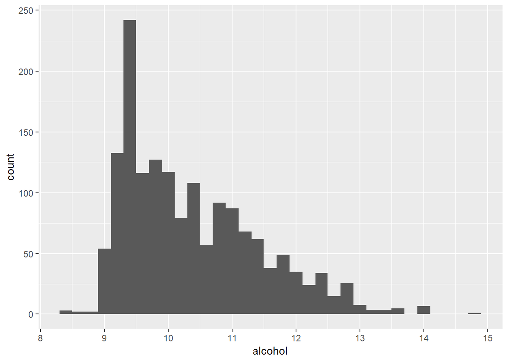

The distribution appears right skewed with a long tail. There seems to be a natural border on the left side.

# Univariate Analysis

### What is the structure of your dataset?

The dataset appears to have 12 variables and 1599 observations, with each observation corresponding to a red wine sample. 11 of the 12 variables appear correspond to the result of a physicochemical test while the (‘quality’) variable appears to correspond to the result of a sensory panel rating.

### What is/are the main feature(s) of interest in your dataset?

The main feature of interest in my dataset is quality rating.

### What other features in the dataset do you think will help support your investigation into your feature(s) of interest?

The physicochemical test results will help support the investigation since all the 11 variables are related to characteristics which may affect the flavor of the wine. Some of the variables may have strong correlation with each other.

### Did you create any new variables from existing variables in the dataset?

No I did not create any new variables from existing variables in the dataset.

### Of the features you investigated, were there any unusual distributions? Did you perform any operations on the data to tidy, adjust, or change the form of the data? If so, why did you do this?

No since the dataset presented is already tidy so there was no unusual distributions, no missing values and no need to adjust the data.

# Bivariate Plots Section

## Fixed Acidity vs. Quality

```
## [1] "Median of fixed.acidity by quality:"
## redwines$quality: 3
## [1] 7.5
## --------------------------------------------------------
## redwines$quality: 4
## [1] 7.5
## --------------------------------------------------------
## redwines$quality: 5
## [1] 7.8
## --------------------------------------------------------
## redwines$quality: 6
## [1] 7.9
## --------------------------------------------------------
## redwines$quality: 7
## [1] 8.8
## --------------------------------------------------------
## redwines$quality: 8
## [1] 8.25
```

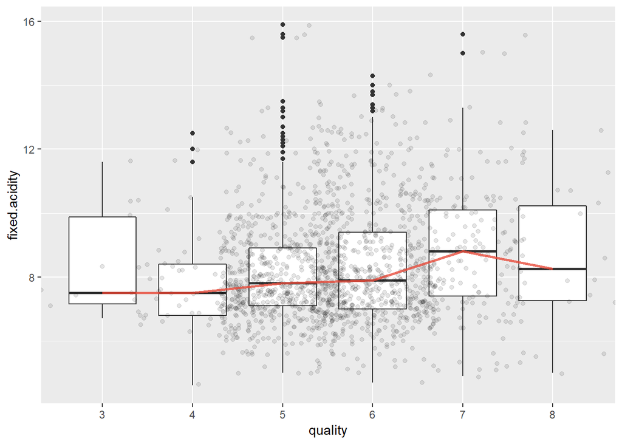

Most of the fixed acidity observations appear to be highly concentrated between quality classes 4 and 7. The median quality of fixed acidity appears to gradually increase from quality classs 4 to 7 then drops between 7 and 8. The higher the fixed acidity seems to mean the higher the wine quality.

## Volatile Acidity vs. Quality

```
## [1] "Median of volatile.acidity by quality:"
## redwines$quality: 3
## [1] 0.845
## --------------------------------------------------------
## redwines$quality: 4
## [1] 0.67
## --------------------------------------------------------
## redwines$quality: 5
## [1] 0.58
## --------------------------------------------------------
## redwines$quality: 6
## [1] 0.49
## --------------------------------------------------------
## redwines$quality: 7
## [1] 0.37
## --------------------------------------------------------
## redwines$quality: 8
## [1] 0.37
```

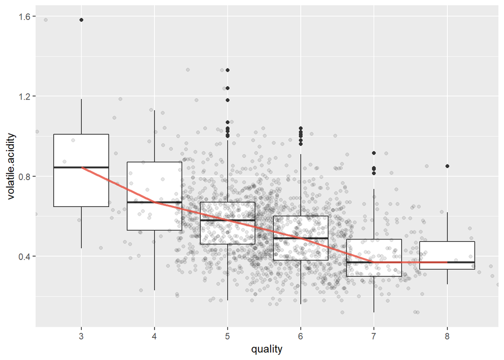

The median quality of volatile acidity appears to gradually decrease from quality classs 3 to 7 then remain flat between 7 and 8. The higher the volalite acidity seems to mean the lower the wine quality.

## Citric Acid vs. Quality

```
## [1] "Median of citric.acid by quality:"
## redwines$quality: 3
## [1] 0.035
## --------------------------------------------------------
## redwines$quality: 4
## [1] 0.09
## --------------------------------------------------------
## redwines$quality: 5
## [1] 0.23
## --------------------------------------------------------
## redwines$quality: 6
## [1] 0.26
## --------------------------------------------------------
## redwines$quality: 7
## [1] 0.4
## --------------------------------------------------------
## redwines$quality: 8
## [1] 0.42
```

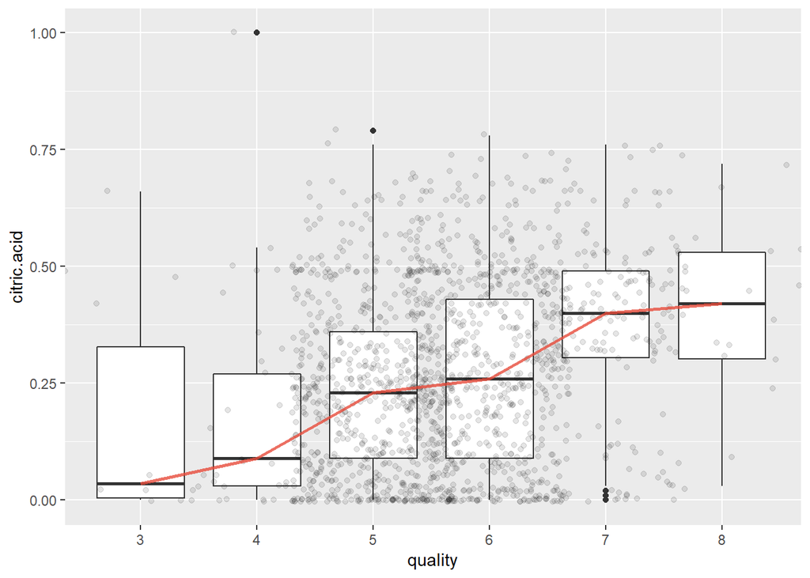

The median quality of volatile acidity appears to increase from quality classs 3 to 8. The higher citric acid seems to mean the higher quality wine.

Looking to see which proportion of wines has zero citric acid.

```
## [1] 0.08255159
```

```
## # A tibble: 6 x 2
##   quality n_zero
##   <ord>    <dbl>
## 1 3       0.3
## 2 4       0.189
## 3 5       0.0837
## 4 6       0.0846
## 5 7       0.0402
## 6 8       0
```

Proportion of wines with zero citric acid appear to decrease as quality classes increase.

## Residual Sugar vs. Quality

```
## [1] "Median of residual.sugar by quality:"
## redwines$quality: 3
## [1] 2.1
## --------------------------------------------------------
## redwines$quality: 4
## [1] 2.1
## --------------------------------------------------------
## redwines$quality: 5
## [1] 2.2
## --------------------------------------------------------
## redwines$quality: 6
## [1] 2.2
## --------------------------------------------------------
## redwines$quality: 7
## [1] 2.3
## --------------------------------------------------------
## redwines$quality: 8
## [1] 2.1
```

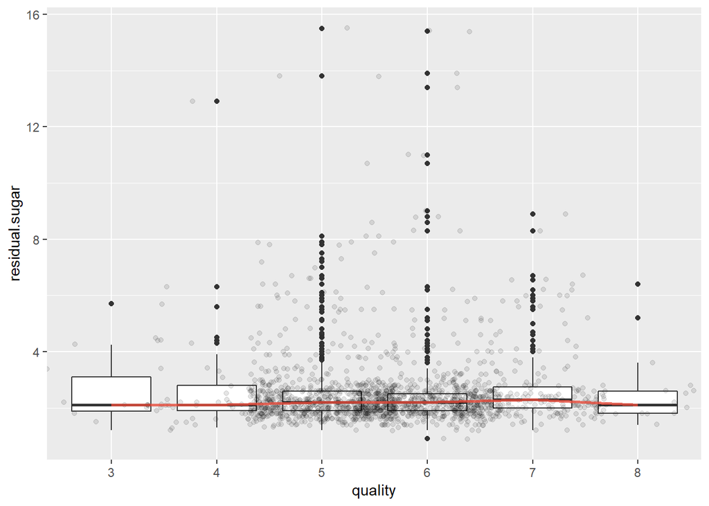

```
## [1] "Median of residual.sugar by quality:"
## redwines$quality: 3
## [1] 2.1
## --------------------------------------------------------
## redwines$quality: 4
## [1] 2.1
## --------------------------------------------------------
## redwines$quality: 5
## [1] 2.2
## --------------------------------------------------------
## redwines$quality: 6
## [1] 2.2
## --------------------------------------------------------
## redwines$quality: 7
## [1] 2.3
## --------------------------------------------------------
## redwines$quality: 8
## [1] 2.1
```

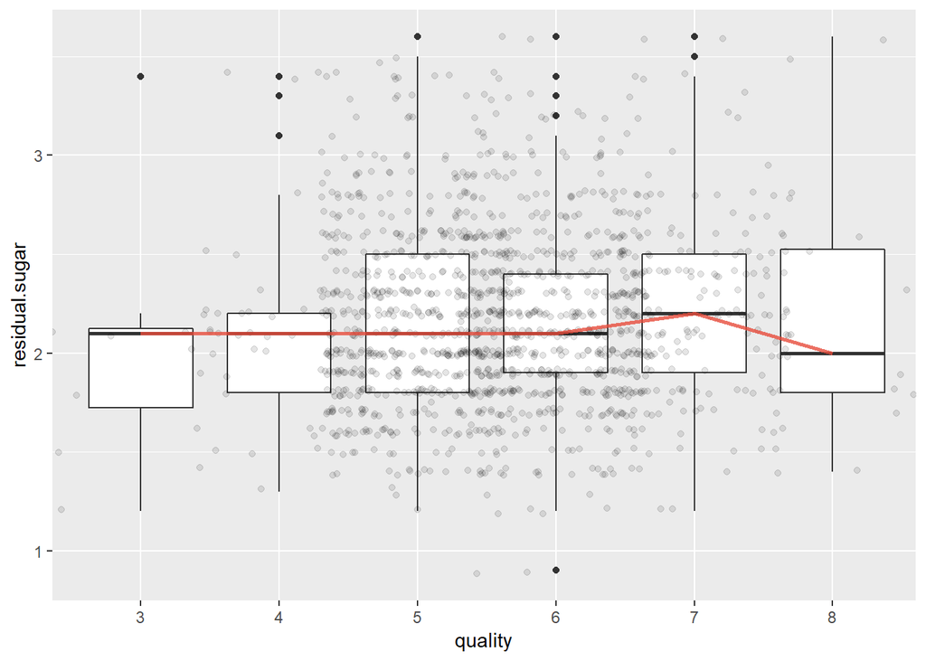

Residual sugar seems to have little or no impact on wine quality.

## Chlorides vs. Quality

```
## [1] "Median of chlorides by quality:"
## redwines$quality: 3
## [1] 0.0905
## --------------------------------------------------------
## redwines$quality: 4
## [1] 0.08
## --------------------------------------------------------
## redwines$quality: 5
## [1] 0.081
## --------------------------------------------------------
## redwines$quality: 6
## [1] 0.078
## --------------------------------------------------------
## redwines$quality: 7
## [1] 0.073
## --------------------------------------------------------
## redwines$quality: 8
## [1] 0.0705
```

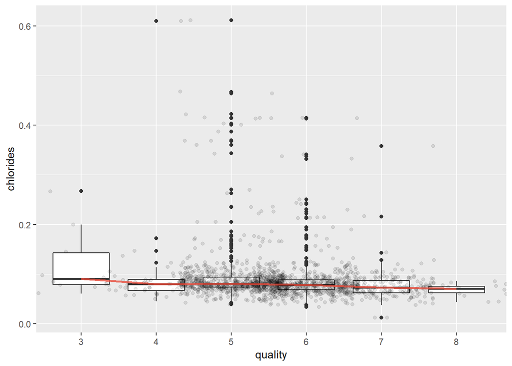

```
## [1] "Median of chlorides by quality:"
## redwines$quality: 3
## [1] 0.0905
## --------------------------------------------------------
## redwines$quality: 4
## [1] 0.08
## --------------------------------------------------------
## redwines$quality: 5
## [1] 0.081
## --------------------------------------------------------
## redwines$quality: 6
## [1] 0.078
## --------------------------------------------------------
## redwines$quality: 7
## [1] 0.073
## --------------------------------------------------------
## redwines$quality: 8
## [1] 0.0705
```

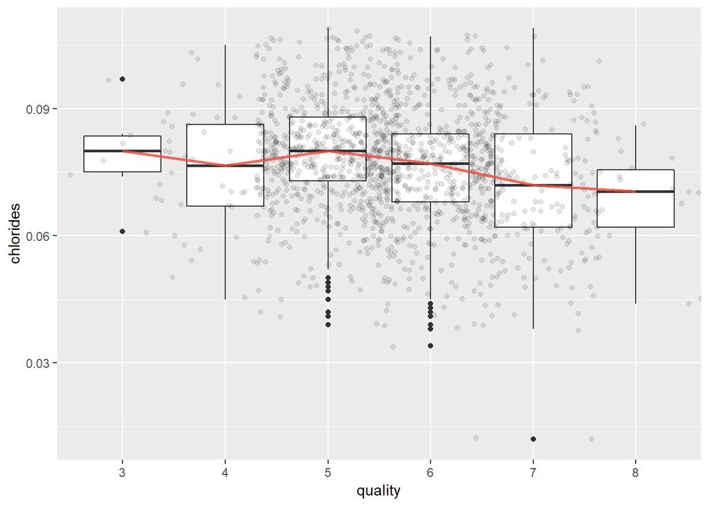

Less chlorides seem to mean higher wine quality but not a very strong correlation.

## Free sulfur dioxide vs. Quality

```
## [1] "Median of free.sulfur.dioxide by quality:"
## redwines$quality: 3
## [1] 6
## --------------------------------------------------------
## redwines$quality: 4
## [1] 11
## --------------------------------------------------------
## redwines$quality: 5
## [1] 15
## --------------------------------------------------------
## redwines$quality: 6
## [1] 14
## --------------------------------------------------------
## redwines$quality: 7
## [1] 11
## --------------------------------------------------------
## redwines$quality: 8
## [1] 7.5
```

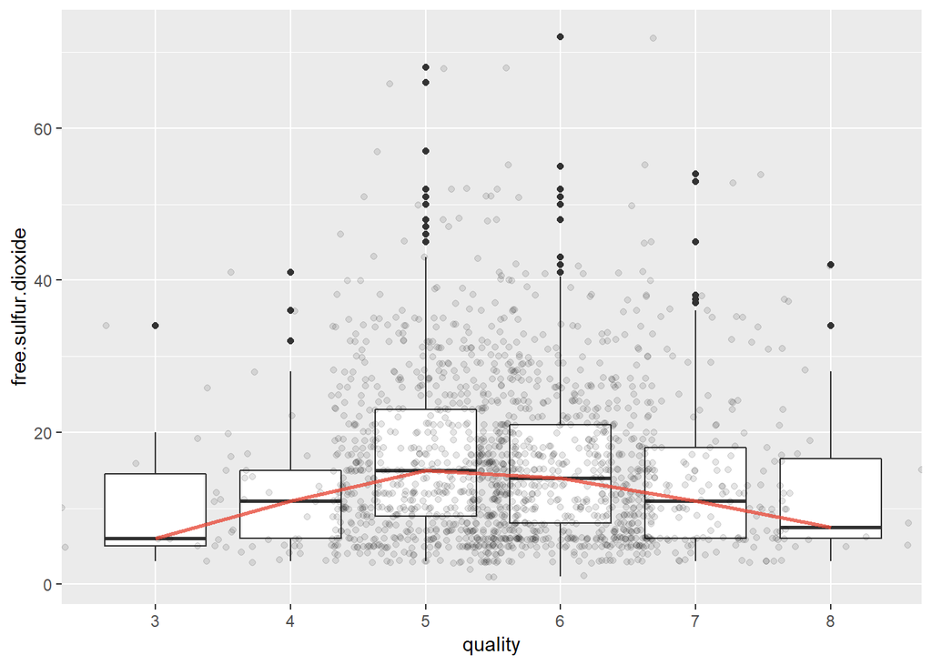

Wine quality appears higher in the middle where there is higher concentration of free sulfur dioxide between quality class 5 and 6 then decreases from there.

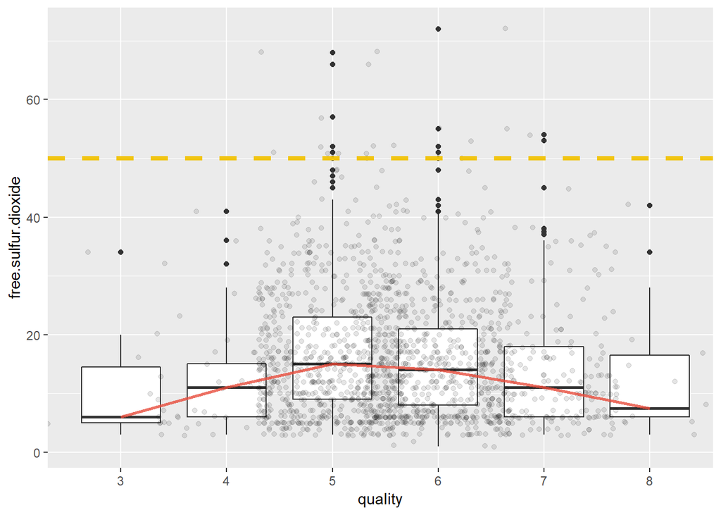

## Total sulfur dioxide vs. Quality

```
## [1] "Median of total.sulfur.dioxide by quality:"
## redwines$quality: 3
## [1] 15
## --------------------------------------------------------
## redwines$quality: 4
## [1] 26
## --------------------------------------------------------
## redwines$quality: 5
## [1] 47
## --------------------------------------------------------
## redwines$quality: 6
## [1] 35
## --------------------------------------------------------
## redwines$quality: 7
## [1] 27
## --------------------------------------------------------
## redwines$quality: 8
## [1] 21.5
```

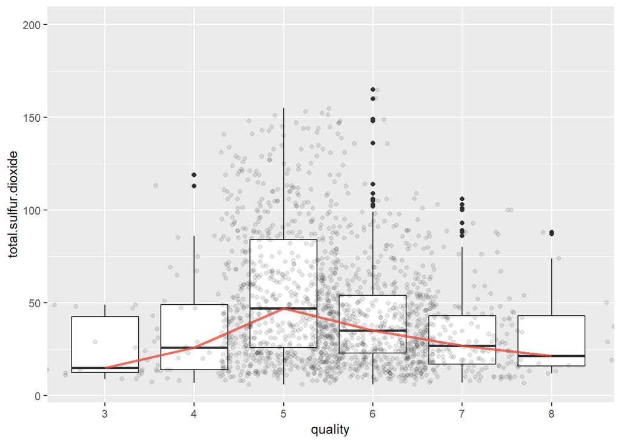

Wine quality appears higher in the middle where there is higher concentration of totoal sulfur dioxide at quality class 5 then starts decreasing from there.

## Density vs. Quality

```
## [1] "Median of density by quality:"
## redwines$quality: 3
## [1] 0.997565
## --------------------------------------------------------
## redwines$quality: 4
## [1] 0.9965
## --------------------------------------------------------
## redwines$quality: 5
## [1] 0.997
## --------------------------------------------------------
## redwines$quality: 6
## [1] 0.99656
## --------------------------------------------------------
## redwines$quality: 7
## [1] 0.99577
## --------------------------------------------------------
## redwines$quality: 8
## [1] 0.99494
```

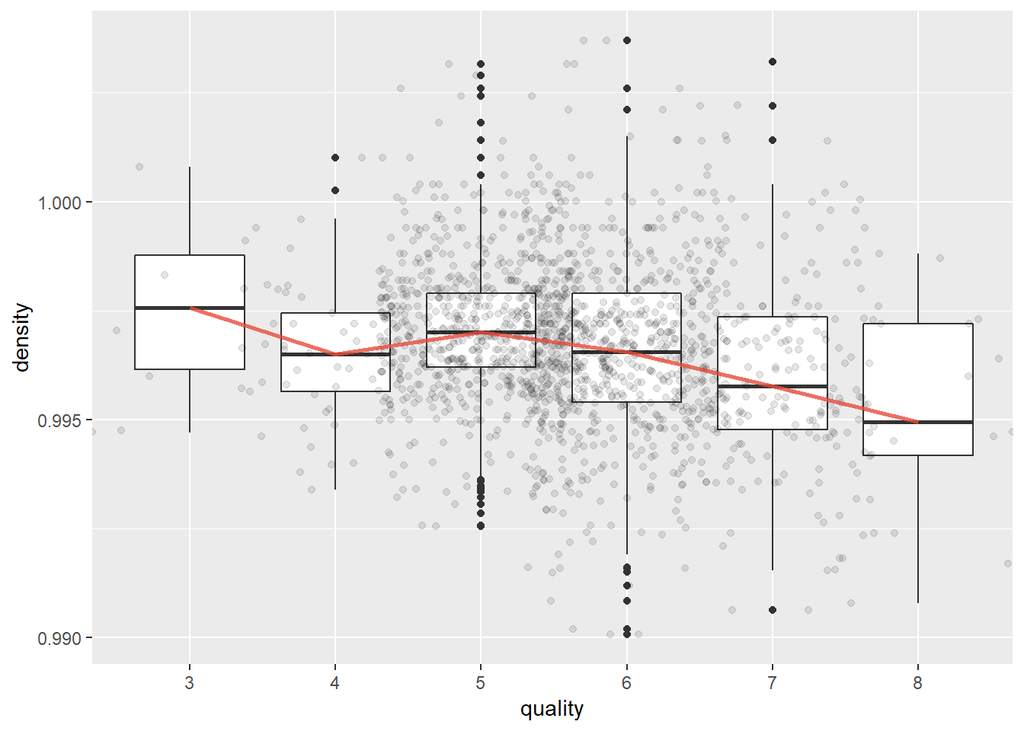

## pH vs. Quality

```
## [1] "Median of pH by quality:"
## redwines$quality: 3
## [1] 3.39
## --------------------------------------------------------
## redwines$quality: 4
## [1] 3.37
## --------------------------------------------------------
## redwines$quality: 5
## [1] 3.3
## --------------------------------------------------------
## redwines$quality: 6
## [1] 3.32
## --------------------------------------------------------
## redwines$quality: 7
## [1] 3.28
## --------------------------------------------------------
## redwines$quality: 8
## [1] 3.23
```

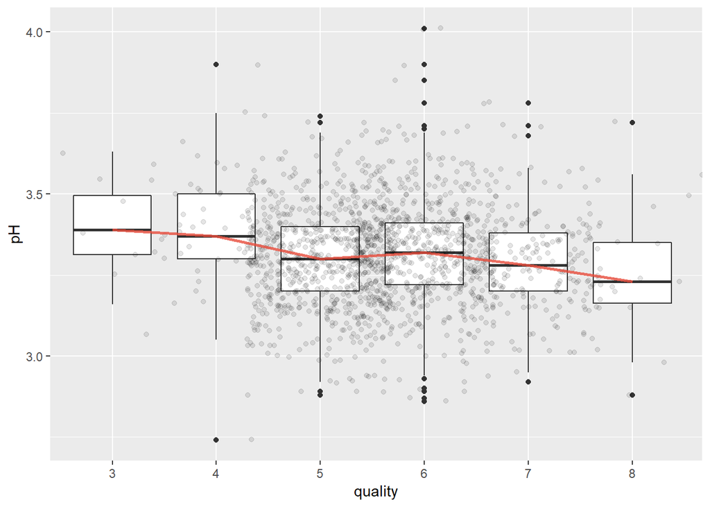

There seems to be a trend of higher quality with lower pH

## Sulphates vs. Quality

```
## [1] "Median of sulphates by quality:"
## redwines$quality: 3
## [1] 0.545
## --------------------------------------------------------
## redwines$quality: 4
## [1] 0.56
## --------------------------------------------------------
## redwines$quality: 5
## [1] 0.58
## --------------------------------------------------------
## redwines$quality: 6
## [1] 0.64
## --------------------------------------------------------
## redwines$quality: 7
## [1] 0.74
## --------------------------------------------------------
## redwines$quality: 8
## [1] 0.74
```

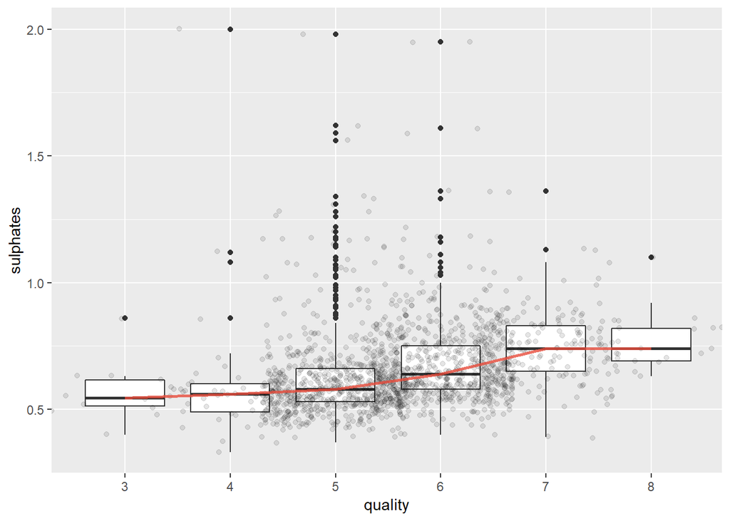

```
## [1] "Median of sulphates by quality:"
## redwines$quality: 3
## [1] 0.545
## --------------------------------------------------------
## redwines$quality: 4
## [1] 0.56
## --------------------------------------------------------
## redwines$quality: 5
## [1] 0.58
## --------------------------------------------------------
## redwines$quality: 6
## [1] 0.64
## --------------------------------------------------------
## redwines$quality: 7
## [1] 0.74
## --------------------------------------------------------
## redwines$quality: 8
## [1] 0.74
```

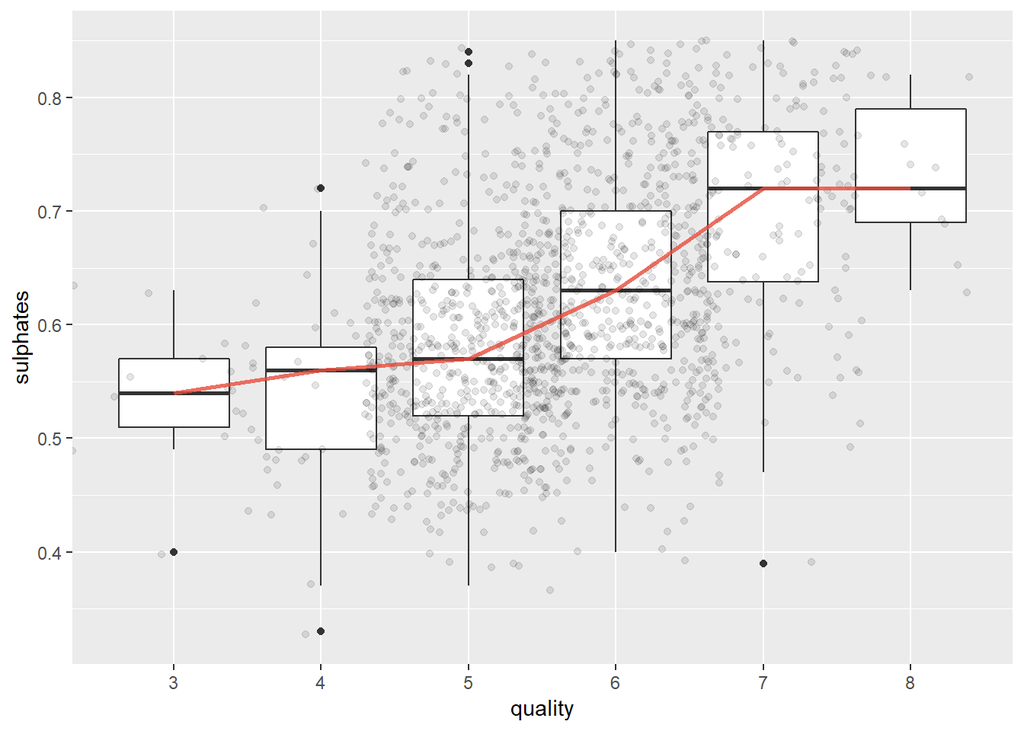

Higher sulphates concentration means higher quality.

## Alcohol vs. Quality

```
## [1] "Median of alcohol by quality:"
## redwines$quality: 3
## [1] 9.925
## --------------------------------------------------------
## redwines$quality: 4
## [1] 10
## --------------------------------------------------------
## redwines$quality: 5
## [1] 9.7
## --------------------------------------------------------
## redwines$quality: 6
## [1] 10.5
## --------------------------------------------------------
## redwines$quality: 7
## [1] 11.5
## --------------------------------------------------------
## redwines$quality: 8
## [1] 12.15
```

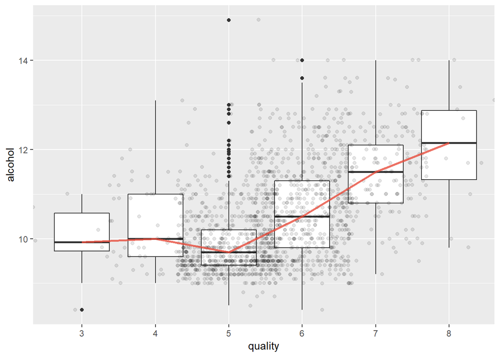

Aside from the dip at the quality class 5, the higher the alcohol content, the higher quality.